# BEE552_problem_set_2

Roy Nunez

2/1/2018

Question 1 (1 pt each) Let X be a discrete random variable whose pdf is described in the table given here: x -1 0 1 f(x) 1/8 6/8 1/8

FInd the following: a) P(X=0) =
$$a) P(X=0) =\frac{6}{8}$$
b) P(X<1) =
$$b) P(X<1) = \frac{7}{8}$$
c) P(X≤1) =
$$c) P(X≤1) = 1$$
d) F(1) =
$$c) F(1) = 1$$
e) F(1) =
$$c) F^1\left(\frac{7}{8}\right)= 0$$
f) R(x) =
$$R(x)=1-F(x)$$

Question 2 Assume that leaf biomass (in grams) from the plant Salix arctica can be described as having the following probability density function:
$$f\left(x\right)= \frac{2}{\left(x + 1\right)^3} \hspace{2 mm}for\hspace{2 mm} x > 0$$
a) Another way of saying that this pdf is restricted to x>0 is to say that there is no support for x≤0. Why would this be the case here? In this particular situation the pdf is considering biomass. To get a meausre of biomass a value of greater than zero is required. Negative biomass does not apply here. b) Prove (using the two requirements for a valid pdf) that this is a valid pdf. f(x) greater than or equal to 0 for all positive values of x As long as x is bounded by 0 and the conditions of function are met then f(x) will be greater than 0

c) Manually (i.e., using calculus) calculate the probability that a leaf has biomass between 0 g and 3 g. In other words, find P(0<X<3).
$$\int_{0}^{3} \frac{2}{(X +1)^3}= 2\int_{0}^{3}\frac{1}{(u)^3}du$$
$$2\frac{u^-2}{-2} = \frac{2}{-2u^2} = \frac{1}{u^2}=\frac{1}{\left(x+1\right)^2}$$
$$=\frac{1}{\left(3+1\right)^2}- \frac{1}{\left(0+1\right)^2}=\frac{1}{16}-\frac{-1}{1}$$
$$=\frac{15}{16}$$

4. Use the integrate function in R to confirm this result numerically.

```r
integrand<-function(x){2/(x+1)^3}
integrate(integrand,0,3)
```

```
## 0.9375 with absolute error < 5.3e-08
```

Question 3 Bliss and R.A. Fisher (1953) examined female European red mite counts (Panonychus ulmi) on McIntosh apple trees [Malus domestica [McIntosh]). Counts of the mites on 150 leaves are shown here:

Mites per leaf 0 1 2 3 4 5 6 7 8 Leaves observed 70 38 17 10 9 3 2 1 0

1. What is the expected value E[X] of mites per leaf in this sample (show your work, either an R script or a calculation)?

```r
Mites.per.leaf<-c(0,1,2,3,4,5,6,7,8);Leaves.observed<-c(70,38,17,10,9,3,2,1,0)
expect.v<-vector()
for (i in 1:length(Mites.per.leaf)){
  expect.v<-append(expect.v,Mites.per.leaf[i]*Leaves.observed[i]/sum(Leaves.observed))
}
cat("The expected value of mites per leaf in this sample is",sum(expect.v))
```

```
## The expected value of mites per leaf in this sample is 1.146667
```

2. Assume for the moment that Bliss and Fisher used a Poisson distribution to describe the number of mites per leaf X (X~Pois(λ)). What would be the most reasonable value for the Poisson parameter λ and why?

The most reasonable value for the poisson parameter Lambda (λ) for the distribution of mites per leaf would be its expected value, 1.146667. That is because the poisson parameter λ is defined as the variance and mean of the distribution. By the definition as the number of samples increase the mean of a probability distribution will converge with the expected value.

```r
bliss.fisher<-rep(Mites.per.leaf,Leaves.observed)
cat("The expected value of this distribution,",sum(expect.v), "equals it's mean,",mean(bliss.fisher))
```

```
## The expected value of this distribution, 1.146667 equals it's mean, 1.146667
```

3. Make a barplot (the R function histogram should work, but as these are discrete variables, we would normally refer to this as a bar plot) of Bliss and Fisher’s data. Is the expected value also the most common value? Why or why not?

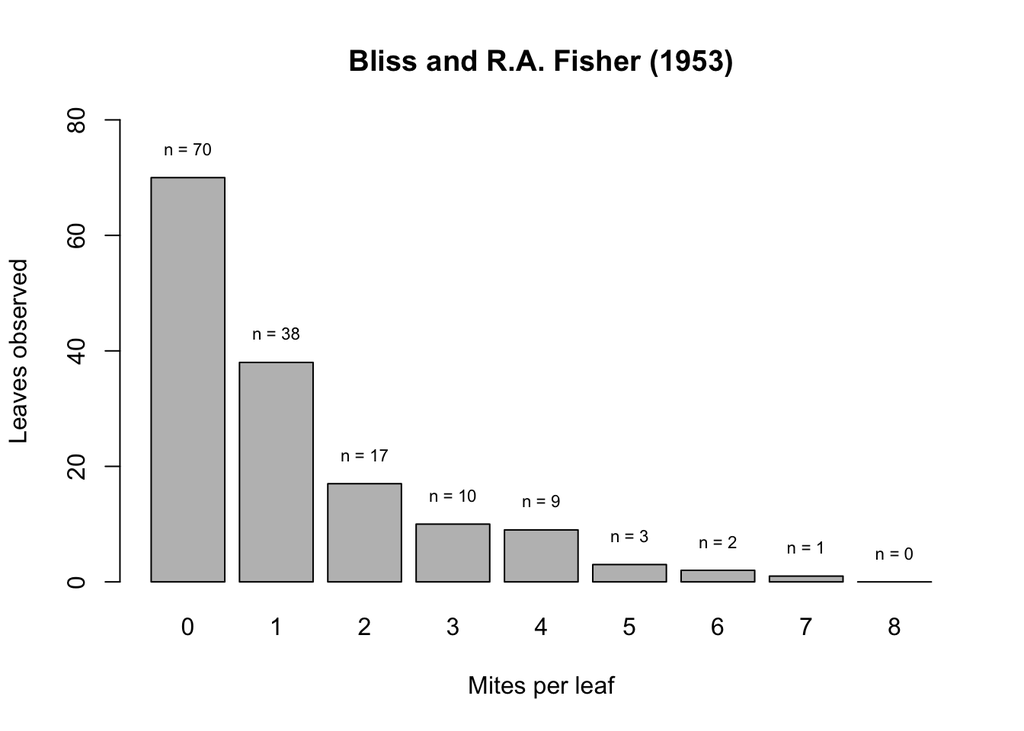

```r
bf<-barplot(setNames(Leaves.observed,Mites.per.leaf), ylim=c(0,80), xlab = "Mites per leaf", ylab = "Leaves observed", main="Bliss and R.A. Fisher (1953)")
text(bf, Leaves.observed +5, paste("n = ",Leaves.observed,sep="") ,cex=.7)
```

4. What is the standard deviation of the number of mites per leaf? What is the standard error of the mean (SEM) number of mites per leaf? In one sentence, describe the interpretation of the standard error of the mean?

```r
#function to compute the standard deviation of a given dataset without using the sd() R predefined function
compute.sigma<-function(dataset){
  x.bar<-mean(dataset)#defining the mean of the data
  temp<-vector();squared.deviation<-vector()
  for(i in seq_along(dataset)){
    temp<-(dataset[i] -x.bar)**2#squared deviation from the mean
    squared.deviation<-sum(squared.deviation,temp)
    sigma<-sqrt(squared.deviation/length(dataset))
  }
  return(sigma)
}
sigma<-compute.sigma(bliss.fisher)

cat("The standard deviation of the number of mites per leaf is",sigma)
```

```
## The standard deviation of the number of mites per leaf is 1.502827
```

```r
#computing standard error of the mean
standard.error.mean<-sigma/sqrt(length(bliss.fisher))
cat("The standard error of the mean number of mites per leaf is",standard.error.mean)
```

```
## The standard error of the mean number of mites per leaf is 0.1227053
```

The SEM is an estimate of the standard deviation of the mean of a population and measures the dispersion of sample means around the population mean.

5. To gain better intuition for the meaning of the standard error of the mean, create 1000 new datasets by sampling with replacement from the original dataset. Use those 1000 simulated datasests to calculate the standard error of the mean. Because of sampling error, this will not be exactly the same as what you calculated in part d, but it should be close. (2 pt BONUS: How would you go about simulating the sampling error of the SEM?)

```r
mites<-c(0,1,2,3,4,5,6,7,8)
observed.counts<-c(70,38,17,10,9,3,2,1,0)
probabilities.obser<-observed.counts/sum(observed.counts)

r.samp.mean<-function(dummy.var){#simulates a dataset with given counts and probablities and returns the mean of the data
  r.samp<-sample(mites,150, replace=TRUE, probabilities.obser)
  return(mean(r.samp))
}
r.samp.mean()
```

```
## [1] 1.28
```

```r
collective.means<-lapply(1:1000,r.samp.mean)#generates a 100 samples and collects their means
cat("The standard error of the mean of my simulated samples is",sd(unlist(collective.means)))
```

```
## The standard error of the mean of my simulated samples is 0.1216542
```

```r
#simulating the sampling error of the SEM
simulate.sem<-function(var){
  r.samp<-sample(mites,150, replace=TRUE, probabilities.obser)
  #sem<-sd(r.samp)/sqrt(length(bliss.fisher))
  sem<-sqrt(var(r.samp)/length(bliss.fisher))
  return(sem)
}
c.sem<-sapply(1:1000,simulate.sem)#generates SEMs of a 1000 sample datasets
#because I observed earlier that it is not a normal distribution I have applied a T-distribution quantile function to obain my margin of error. Because I wish to capture my 95% confidence interval, I will use .975, where the lower and upper bounds are to be defined by mean-sem.sampling.error and mean+sem.sampling.error
sem.sampling.error<-qt(.975,df=length(bliss.fisher)-1)*sd(c.sem)/sqrt(length(bliss.fisher))
cat("My simulated sampling error of the SEM is +/-",sem.sampling.error)
```

```
## My simulated sampling error of the SEM is +/- 0.001669812
```

Part II We are going to get some practice using these statistical distributions in a biological context, and in the process gain some extra practice writing R code. Read Viswanathan et al. (2008) for the biological context of this problem, but don’t worry too much about the mathematical details (you can skim over Section 4).

This question is designed to get you writing some more sophisticated R scripts, with more emphasis on loops and logic, but there are some statistical and biological goals as well. Before getting to the actual question, I want to emphasize the following “take-home” messages: 1. There are many, many statistical distributions. We have learned only a small subset of all the statistical distributions. Long-tailed distributions (such as the Lévy, Cauchy, and Pareto) have many uses in ecology and evolution. 2. Simulations provide a straightforward way of studying complex stochastic phenomena. 3. Understanding ‘pattern’ goes a long way to understanding the underlying ‘process’. Statistical distributions provide a way to quantify the pattern of your data. In many cases, only certain biological or ecological mechanisms can generate those patterns.

Write a short script to simulate the movement of animals operating according to the movement rules described below. For simplicity, we will assume only one-dimensional motion along a line. Animals can move forward, or backwards, along a line. For each animal, simulate 500 individuals each moving for 100 time steps each. Note that only Animal #1 and #2 are required for this problem set (8 pts total). Animals #3 and #4 are BONUS questions (3 pts each). Animal #1: This animal moves by “Brownian” motion. In each time step, the individual chooses a random direction (50% probability of moving forward or backwards [this is a Binomial process!]) and moves a distance given by (the absolute value of) N(μ=0,σ^2=1). (You can do this by combining a Bernoulli for direction with a distance given by the magnitude of the Normal, or just do it in one step by making the movement Normally distributed. The former approach will be more portable to Animals #2-#4.) Cut and paste your script and a histogram of the final location for each of the 500 individuals. Fit a normal distribution to that distribution (hint: use use ‘fitdistr’)- what is μ ̂ and (σ^2 ) ̂?

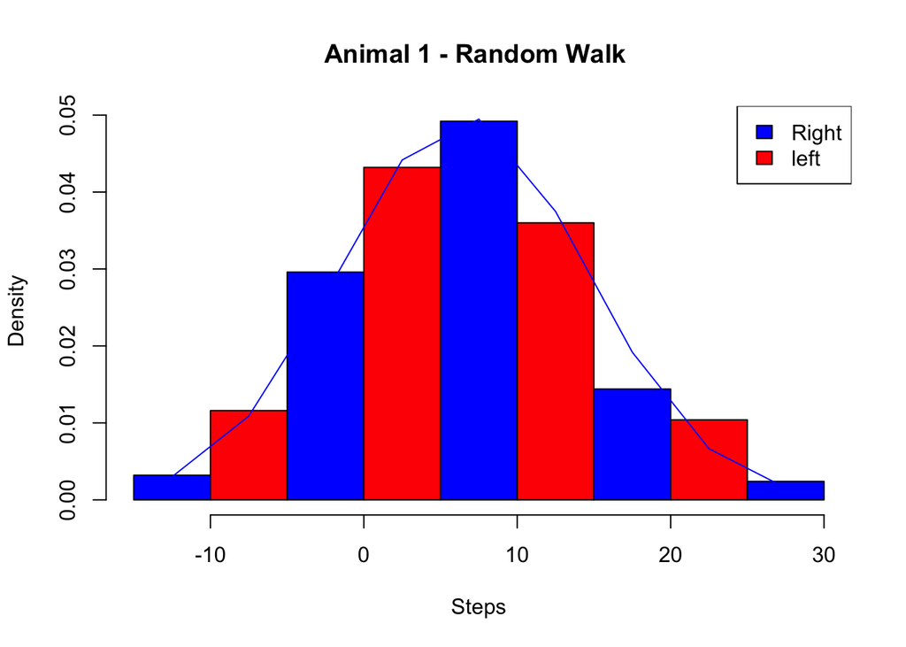

```r
rm(list=ls(all=TRUE))
#Animal 1
t.walk.1<-c()#declaring the global variable to capture function call output
walk.1<-function(steps.2=100){
  distances.a1<- abs(rnorm(100, mean = 0, sd = 1))#defining distance object with random distances
   store.1<-list(step.direction=c(), step.distance=c())#intiating collection list
  for (i in 1:100) {
    if (rbinom(1,1, .5)==1){ #a binomial return of success of fail at .5 probability is compared to one for success. If successful the loop is entered.
      store.1$step.direction[i]<-"right" #direction and distance is stored
      store.1$step.distance[i]<-distances.a1[i]
    }else{
      store.1$step.direction[i]<-"left"
      store.1$step.distance[i]<-distances.a1[i]
    }
  }
  t.walk.1<-append(t.walk.1,store.1)
  return(t.walk.1)#two dimansioanl list returned with direction and distance of every animal
}
tt<-lapply(1:500, walk.1)#function call applied to 500 animals

collect.d<-c();dir<-c();dis<-c()
for (i in 1:500){
  max.d<-names(which.max(table(tt[[i]]$step.direction)))#returns most frequent direction
  total.d<-sum(tt[[i]]$step.distance[which(tt[[i]]$step.direction==max.d)])-sum(tt[[i]]$step.distance[which(tt[[i]]$step.direction!=max.d)])#returns net distance traveled
  collect.d<-append(collect.d,total.d)
  dis<-append(dis,total.d)#net distance and direction are collected for index and stored accordingly by index for merging by index
  dir<-append(dir,max.d)
}

ss<-data.frame(dis,dir,stringsAsFactors = T)#combining net distance with direction
hist1<-hist(ss$dis,col = c("blue","red"), freq = F, main="Animal 1 - Random Walk ", xlab="Steps")
hist(ss$dis,col = c("blue","red"), freq = F, main="Animal 1 - Random Walk ", xlab="Steps")
legend("topright", c("Right", "left"), fill=c("blue", "red"))

library(MASS)#library required for following steps
ft1<-fitdistr(ss$dis, "normal") # Maximum-likelihood fitting of normal distributions
mean1<-ft1$estimate[1] #storing estimates
sd1<-ft1$estimate[2]
dnorm1<-dnorm(hist1$mids, mean = mean1 , sd=  sd1 ) # create the y coordinate for the line to look at normal
lines(hist1$mids, dnorm1, col = "blue") # provide x and y coordinates to creat line (use mid points)
```

```r
cat("The estimated standard deviation is",ft1$estimate[2])
```

```
## The estimated standard deviation is 7.994498
```

```r
cat("The estimated mean is",ft1$estimate[1])
```

```
## The estimated mean is 6.448724
```

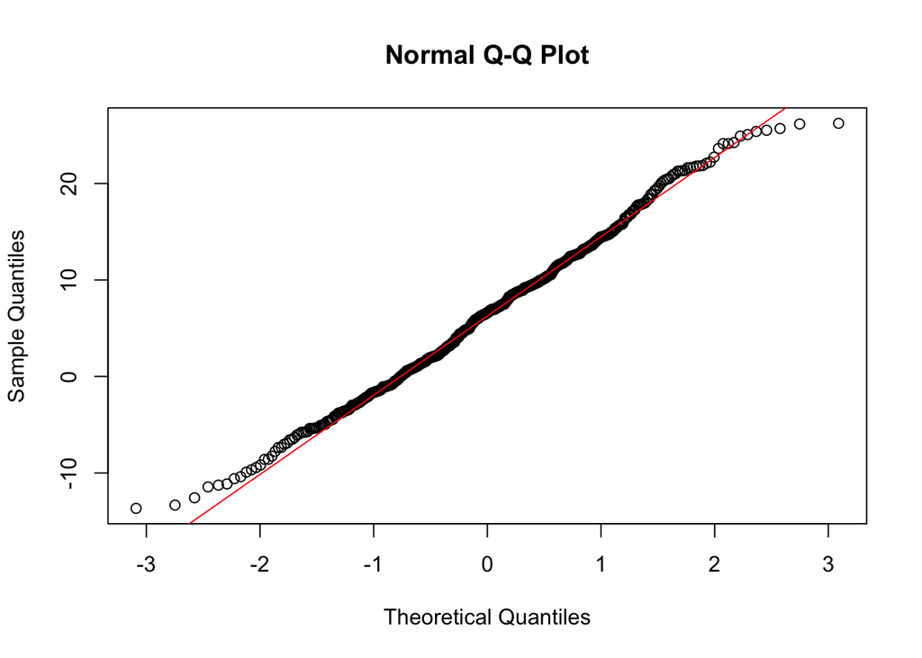

```r
qqnorm(ss$dis)
qqline(ss$dis, col="red")
```

```r
# The quantile-quantile plot allows a comparison with the normal distribution, if qq plot's line fit the data then this is greater affirmation that is is a normal distribution, as it appears.
```

Animal #2: This animal is similar to Animal #1 but it preferentially moves to the right. In each time step, there is a 60% chance the animal will move to the right, the distance moved is still given by N(μ=0,σ^2=1). Cut and paste your script and a histogram of the final location for each of the 500 individuals. Fit a normal distribution to that distribution (hint: use use ‘fitdistr’)- what is μ ̂ and (σ^2 ) ̂ now? Note that this is still a random walk, albeit one with drift.

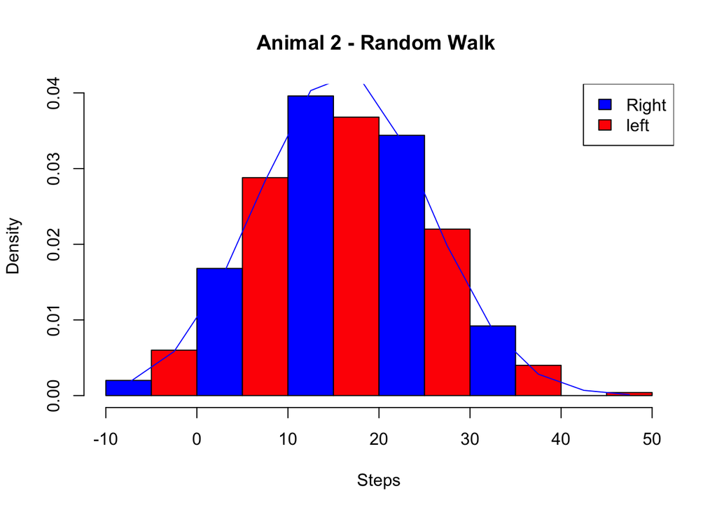

```r
#Animal 2
rm(list=ls(all=TRUE))
t.walk.2<-c()

animal.2<-function(steps.2=100){
  store.2<-list(step.direction=c(), step.distance=c())
  distances.a2<- abs(rnorm(100, mean = 0, sd = 1))
  for (i in 1:100) {
    if (rbinom(1,1, .6)==1){
      store.2$step.direction[i]<-"right"
      store.2$step.distance[i]<-distances.a2[i]
    }else{
      store.2$step.direction[i]<-"left"
      store.2$step.distance[i]<-distances.a2[i]
    }
  }
  t.walk.2<-append(t.walk.2,store.2)
  return(t.walk.2)
}
tt<-lapply(1:500, animal.2)

collect.d<-c();dir<-c();dis<-c()
for (i in 1:500){
  max.d<-names(which.max(table(tt[[i]]$step.direction)))
  total.d<-sum(tt[[i]]$step.distance[which(tt[[i]]$step.direction==max.d)])-sum(tt[[i]]$step.distance[which(tt[[i]]$step.direction!=max.d)])
  collect.d<-append(collect.d,total.d)
  dis<-append(dis,total.d)
  dir<-append(dir,max.d)
}

ss<-data.frame(dis,dir,stringsAsFactors = T)#combining net distance with direction
hist2<-hist(ss$dis,col = c("blue","red"), freq = F, main="Animal 2 - Random Walk ", xlab="Steps")
hist(ss$dis,col = c("blue","red"), freq = F, main="Animal 2 - Random Walk ", xlab="Steps")
legend("topright", c("Right", "left"), fill=c("blue", "red"))

library(MASS)#library required for following steps
ft2<-fitdistr(ss$dis, "normal") # Maximum-likelihood fitting of normal distributions
mean2<-ft2$estimate[1] #storing estimates
sd2<-ft2$estimate[2]
dnorm2<-dnorm(hist2$mids, mean = mean2 , sd=  sd2 ) # create the y coordinate for the line to look at normal
lines(hist2$mids, dnorm2, col = "blue") # provide x and y coordinates to creat line (use mid points)
```

```r
cat("The estimated standard deviation is",ft2$estimate[2])
```

```
## The estimated standard deviation is 9.222037
```

```r
cat("The estimated mean is",ft2$estimate[1])
```

```
## The estimated mean is 15.96448
```

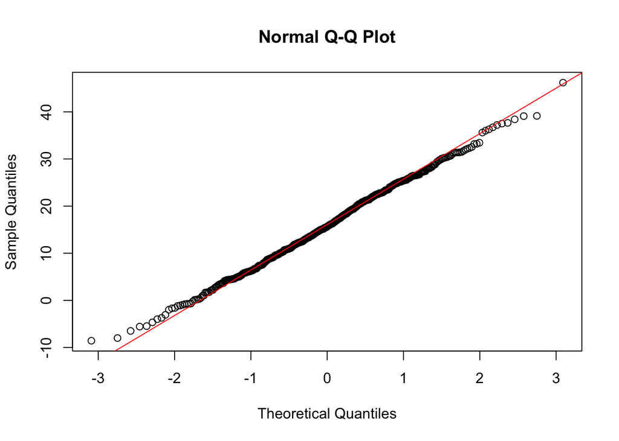

```r
?qqnorm
qqnorm(ss$dis)
qqline(ss$dis, col="red")
```

```r
# The quantile-quantile plot allows a comparison with the normal distribution, if qq plot's line, a 45-degree reference line, fit the data then this is greater affirmation that is is a normal distribution. \
```

Animal #3: This animal walks with a certain amount of inertia. Distances are still given by N(μ=0,σ^2=1), but the probability of moving to the left or right depends on the previous move. The first move is random (50% chance of both left and right) but all subsequent moves have a 60% chance of being in the same direction as the previous move. Cut and paste your script and a histogram of the final location for each of the 500 individuals. Is the resulting distribution still normally distributed? If not, how does the final distribution of individuals differ from a normal? Why?

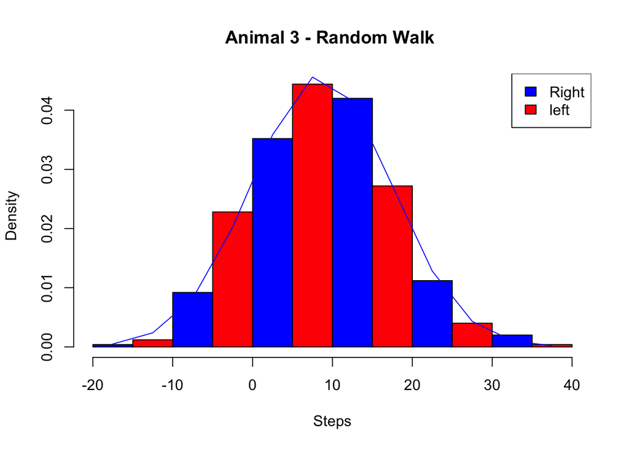

```r
#animal.3
rm(list=ls(all=TRUE))
right.left<-c("right","left")#declaring my direction variables
#this function will simulate a success or fail outcome with given input probablity, and return input direction variable if sucessful or the opposite of input variable if not successful
StepF<-function(p, direction){
  if (rbinom(1,1,p)== 1){
    return(direction)
  } else {
    return(right.left[right.left!=direction])
  }
}

take<-c()
random.walk<-function(num){
  n.steps=100
  distances<- abs(rnorm(n.steps, mean = 0, sd = 1))#generates random distances for each step
  steps<-ifelse(rbinom(1,1, .5)==1, "right","left")#this generates the first step with a .50 probability of going in either direction
  store<-list(step.direction=c(), step.distance=c())
  for( i in 1:n.steps){
    if (steps[i] == StepF(.6,steps[i]) ){#calls on function StepF and compares output with current step. If there is a match it will store direction in the following step.
      steps[[i+1]]<-steps[i]
      store$step.direction[i]<-steps[i]#list store keeps track of directions and distance for every index
      store$step.distance[i]<-distances[i]
    } else {#if the return from function call StepF does not match current step element/direction, it will access the right.left step direction object and return the opposite match to store in the subsequent step
      steps[[i+1]]<-right.left[steps[i]!=right.left]
      store$step.direction[i]<-steps[i]
      store$step.distance[i]<-distances[i]
    }
  }
  take<-append(take,store)
  return(take)
}
tt<-lapply(1:500, random.walk)

collect.d<-c();dir<-c();dis<-c()
for (i in 1:500){
    max.d<-names(which.max(table(tt[[i]]$step.direction)))
    total.d<-sum(tt[[i]]$step.distance[which(tt[[i]]$step.direction==max.d)])-sum(tt[[i]]$step.distance[which(tt[[i]]$step.direction!=max.d)])
    collect.d<-append(collect.d,total.d)
    dis<-append(dis,total.d)
    dir<-append(dir,max.d)
}
ss<-data.frame(dis,dir,stringsAsFactors = T)#combining net distance with direction
hist3<-hist(ss$dis,col = c("blue","red"), freq = F, main="Animal 3 - Random Walk ", xlab="Steps")
hist(ss$dis,col = c("blue","red"), freq = F, main="Animal 3 - Random Walk ", xlab="Steps")

legend("topright", c("Right", "left"), fill=c("blue", "red"))

library(MASS)#library required for following steps
fit3<-fitdistr(ss$dis, "normal") # Maximum-likelihood fitting of normal distributions
mean3<-fit3$estimate[1] #storing estimates
sd3<-fit3$estimate[2]
dnorm3<-dnorm(hist3$mids, mean = mean3 , sd=  sd3 ) # create the y coordinate for the line to look at normal
lines(hist3$mids, dnorm3, col = "blue") # provide x and y coordinates to creat line (use mid points)
```

```r
cat("The estimated standard deviation is",fit3$estimate[2])
```

```
## The estimated standard deviation is 8.67733
```

```r
cat("The estimated mean is",fit3$estimate[1])
```

```
## The estimated mean is 8.622836
```

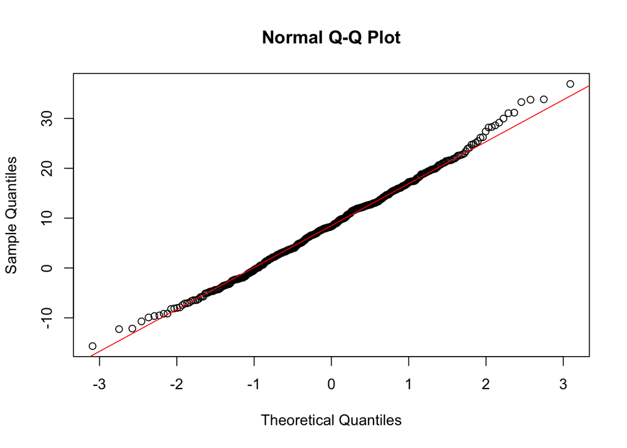

```r
qqnorm(ss$dis)
qqline(ss$dis, col="red")
```

```r
# The quantile-quantile plot allows a comparison with the normal distribution, if qq plot's line, a 45-degree reference line, fit the data then this is greater affirmation that is is a normal distribution.
```

Animal #4: This animal has no preference for direction, so has a 50/50 chance of moving left or right at each time step. However, distances travelled are now NOT normally distributed, but are governed by the Cauchy distribution with location=0 and scale=2 [Hint: Use ‘rcauchy’]. The Cauchy distribution is ‘pathological’ in that is has no mean and no variance; in fact, none of the moments of the Cauchy are defined. The Cauchy is one of the so-called ‘heavy-tailed’ distributions, in that the probability of very large values declines more slowly than the exponential distribution. (Translation: Very large numbers are more likely with heavy-tailed distributions.) In this context, the Cauchy distribution will yield a lot of small moves and some very large moves. Cut and paste your script and a histogram of the final location for each of the 500 individuals. Is the resulting distribution still normally distributed? If not, how does the final distribution of individuals differ from a normal? Why?

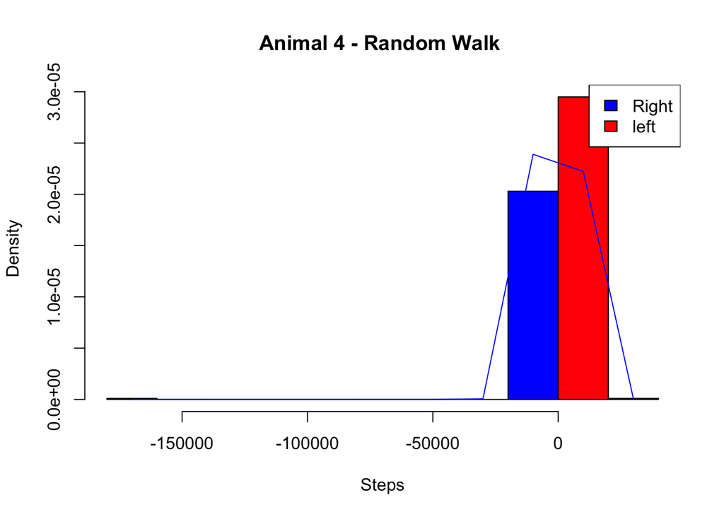

```r
#Animal 4
rm(list=ls(all=TRUE))
take<-c()
animal.4<-function(ff){
  distances.a4<- abs(rcauchy(100,location = 0,scale = 2))
  store.4<-list(step.direction=c(), step.distance=c())
  for (i in 1:100){
    if (rbinom(1,1, .5)==1){
      store.4$step.direction[i]<-"right"
      store.4$step.distance[i]<-distances.a4[i]
    }else{
      store.4$step.direction[i]<-"left"
      store.4$step.distance[i]<-distances.a4[i]
    }
  }
  take<-append(take,store.4)
  return(take)
}
tt<-lapply(1:500, animal.4)

collect.d<-c();dir<-c();dis<-c()
for (i in 1:500){
  max.d<-names(which.max(table(tt[[i]]$step.direction)))
  total.d<-sum(tt[[i]]$step.distance[which(tt[[i]]$step.direction==max.d)])-sum(tt[[i]]$step.distance[which(tt[[i]]$step.direction!=max.d)])
  collect.d<-append(collect.d,total.d)
  dis<-append(dis,total.d)
  dir<-append(dir,max.d)
}

ss<-data.frame(dis,dir,stringsAsFactors = T)#combining net distance with direction
hist4<-hist(ss$dis,col = c("blue","red"), freq = F, main="Animal 4 - Random Walk ", xlab="Steps")
hist(ss$dis,col = c("blue","red"), freq = F, main="Animal 4 - Random Walk ", xlab="Steps")
legend("topright", c("Right", "left"), fill=c("blue", "red"))

library(MASS)#library required for following steps
fit4<-fitdistr(ss$dis, "normal") # Maximum-likelihood fitting of normal distributions
mean4<-fit4$estimate[1] #storing estimates
sd4<-fit4$estimate[2]
dnorm4<-dnorm(hist4$mids, mean = mean4 , sd=  sd4 ) # create the y coordinate for the line to look at normal
lines(hist4$mids, dnorm4, col = "blue") # provide x and y coordinates to creat line (use mid points)
```

```r
cat("The estimated standard deviation is",fit4$estimate[2])
```

```
## The estimated standard deviation is 8152.066
```

```r
cat("The estimated mean is",fit4$estimate[1])
```

```
## The estimated mean is -240.2121
```

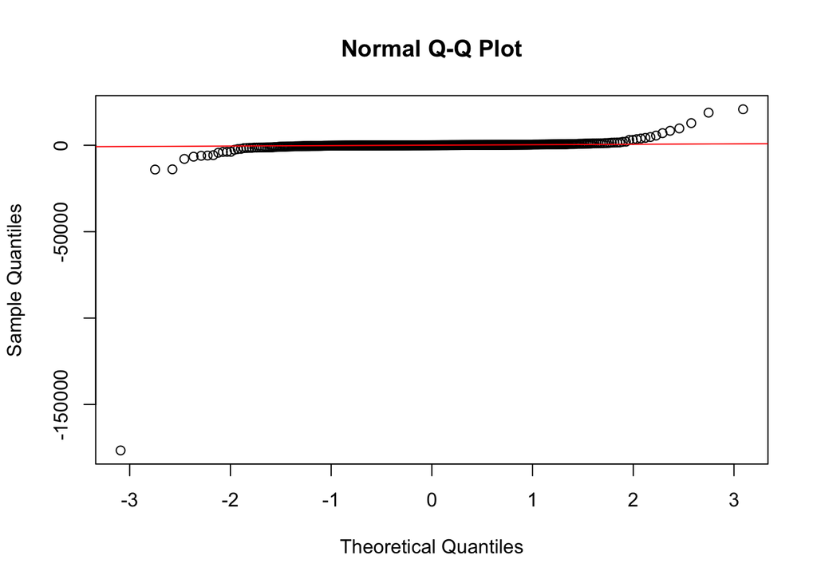

```r
qqnorm(ss$dis)
qqline(ss$dis, col="red")
```

```r
?qqline
# In this example, we have a clear deviation from the qq line. This is evidence that demonstrates that this distribution is not normally distributed.
```

The distribution of this simulation has no resemblance at all to the normal distribution. This cauchy distribution does not have defined moments, particularly the expected value and variance parameters, which are characteristics of a normal distribution. However, its mode and median are well defined and are both equal to X-naught. There is a noticible deviation from the normal where the distribution is concentrated near is median.